# **Over the time growth of Electric Vehicles industry**

Muhammad Aamir Abbas

[Link to our GitHub webpage](https://mabbas128.github.io/mabbas2.github.io/)

# **Introduction:**

In recent years, there has been a notable surge in electric vehicle production. This growth in the EV industry is driven by several factors, including environmental benefits, lower operating costs, energy efficiency, government incentives, improved performance, energy independence, and the expansion of charging infrastructure.

In this project I plan to analyze a dataset containing information of electric vehicles in washington state to observe the trend of this growing industry and based on current market try to predict future of electric vehicles i.e., Top manufacturers, rate of change in the frequency of production each year, improvements in the range of E-vehicles with the passage of time. In this toturial readers will get to know all the above-mentioned analysis.

# **Project Proposal**

I plan to analyze a dataset containing information on electric vehicles in Washington State.The dataset is obtained from [link text](https://catalog.data.gov/dataset/electric-vehicle-population-data).

Utilizing both the data analysis techniques I have learned and those I will acquire throughout the course, my project aims to explore the following key questions:

**Final Model goals:**

1. In the final notebook we want to predict the total number electric vehicles in Washington state after 10 years based on current trends of year vs number of cars produced by all the manufacturers?
2. Additionally, I aim to forecast the leading electric vehicle manufacturers in 20 years by analyzing and comparing their current growth trajectories.

# **Extraction, Transform, and Load (ETL):**

The obtained dataset was then extracted and loaded it as a Pandas dataframe. The dataset contains information regarding all the sold electric cars in Washington state such as customer name, address, car model, type of vehicle, company, and range.

```python
import requests
from bs4 import BeautifulSoup
import pandas as pd
import re
import numpy as np
import matplotlib.pyplot as plt
url = "https://data.wa.gov/api/views/f6w7-q2d2/rows.csv?accessType=DOWNLOAD"
headers = {"User-Agent": "Mozilla/5.0"}
response = requests.get(url, headers=headers)
soup = BeautifulSoup(response.text, 'html.parser')
# Read the CSV into a Pandas DataFrame
EV_df = pd.read_csv(url)
EV_df.to_csv('EV_df.csv', index=False)
EV_df.head()
```

|  | VIN (1-10) | County | City | State | Postal Code | Model Year | Make | Model | Electric Vehicle Type | Clean Alternative Fuel Vehicle (CAFV) Eligibility | Electric Range | Base MSRP | Legislative District | DOL Vehicle ID | Vehicle Location | Electric Utility | 2020 Census Tract |
| --- | --- | --- | --- | --- | --- | --- | --- | --- | --- | --- | --- | --- | --- | --- | --- | --- | --- |
| 0 | 1C4JJXP68P | Yakima | Yakima | WA | 98901.0 | 2023 | JEEP | WRANGLER | Plug-in Hybrid Electric Vehicle (PHEV) | Not eligible due to low battery range | 21.0 | 0.0 | 15.0 | 249905295 | POINT (-120.50729 46.60464) | PACIFICORP | 5.307700e+10 |
| 1 | 1G1FY6S03L | Kitsap | Kingston | WA | 98346.0 | 2020 | CHEVROLET | BOLT EV | Battery Electric Vehicle (BEV) | Clean Alternative Fuel Vehicle Eligible | 259.0 | 0.0 | 23.0 | 141133765 | POINT (-122.4977 47.79802) | PUGET SOUND ENERGY INC | 5.303594e+10 |
| 2 | KNDCE3LG9K | King | Seattle | WA | 98125.0 | 2019 | KIA | NIRO | Battery Electric Vehicle (BEV) | Clean Alternative Fuel Vehicle Eligible | 239.0 | 0.0 | 46.0 | 3410074 | POINT (-122.30253 47.72656) | CITY OF SEATTLE - (WA)\|CITY OF TACOMA - (WA) | 5.303300e+10 |
| 3 | 1N4AZ0CP8E | Thurston | Olympia | WA | 98506.0 | 2014 | NISSAN | LEAF | Battery Electric Vehicle (BEV) | Clean Alternative Fuel Vehicle Eligible | 84.0 | 0.0 | 22.0 | 182436474 | POINT (-122.87741 47.05997) | PUGET SOUND ENERGY INC | 5.306701e+10 |
| 4 | 5YJXCAE29L | Kitsap | Silverdale | WA | 98383.0 | 2020 | TESLA | MODEL X | Battery Electric Vehicle (BEV) | Clean Alternative Fuel Vehicle Eligible | 293.0 | 0.0 | 23.0 | 1843054 | POINT (-122.69275 47.65171) | PUGET SOUND ENERGY INC | 5.303509e+10 |

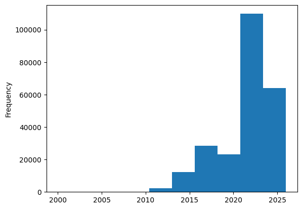

```python
EV_df["Model Year"].plot.hist()
plt.savefig("histogram.png")  # Save the histogram
plt.show()
from IPython.display import display
from PIL import Image
```

**A scatter plot is used to display the electric range achieved by manufacturers each year. The data reveals an interesting trend: in the early 2000s, only a limited number of models were available, offering electric ranges of around 50 miles. As time progressed, more manufacturers entered the market, introducing a greater variety of models with improved ranges. By 2020, the maximum range had increased to approximately 350 miles, with many other range options also available to consumers.**

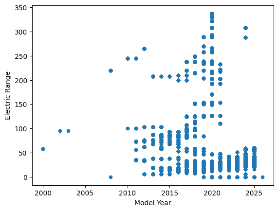

```python
EV_df.plot.scatter(x="Model Year", y="Electric Range")
plt.savefig("histogram.png")  # Save the histogram
plt.show()
from IPython.display import display
from PIL import Image
```

**The next plot shows the distributing number of vehicles based on their type either BEV or PHEV. Before going to the plot its important to know the difference between both types. The main difference between a Battery Electric Vehicle (BEV) and a Plug-in Hybrid Electric Vehicle (PHEV) lies in their power sources and how they operate:**

1. Battery Electric Vehicle (BEV) Runs entirely on electricity stored in a large battery pack.
2. Must be plugged in to charge.
3. Zero tailpipe emissions since there's no fuel combustion.
4. Typically has longer electric-only range than PHEVs.

Plug-in Hybrid Electric Vehicle (PHEV) on the other hand:

1. Has both an electric motor and an internal combustion engine.
2. Can run on electricity alone for a limited range (usually 20–50 miles).
3. After the electric range is used up, the gas engine takes over.
4. Must be plugged in to charge the battery, but can also refuel with gas.
5. Emits tailpipe emissions only when the gas engine is running. **The following plot shows the count of BEV more than 150000, whereas PHEV based vehicles are approximately 50000.**

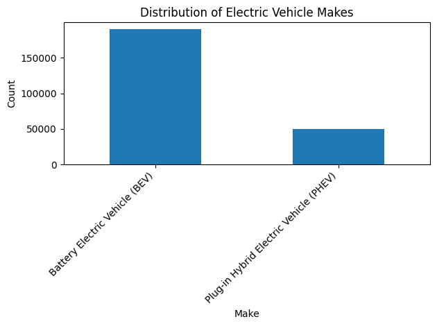

```python
EV_df["Electric Vehicle Type"].value_counts().plot(kind="bar")
plt.title("Distribution of Electric Vehicle Makes")
plt.xlabel("Make")
plt.ylabel("Count")
plt.xticks(rotation=45, ha='right')  # Rotate x-axis labels for better readability
plt.tight_layout()  # Adjust layout to prevent labels from overlapping
plt.savefig("make_distribution.png")  # Save the bar chart
plt.show()
from IPython.display import display
from PIL import Image
```

**Data Tidying**

**Removing the state column since all the dataset is from the same state (Washinton)**

```python
EV_df = EV_df.drop('State', axis=1)
```

**The next bar chart displays the total number of electric vehicles produced by each company, highlighting the leading manufacturers in the industry. It is evident that Tesla dominates the market, with an impressive total exceeding 100,000 vehicles in Washington state alone. Other major contributors include Chevrolet, Nissan, Kia, and others.**

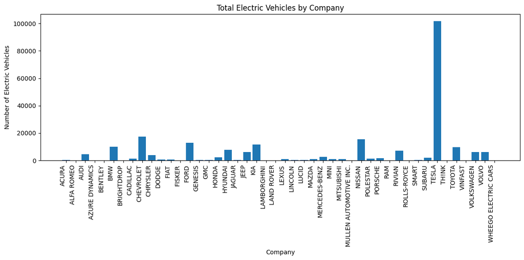

```python
company_counts = EV_df.groupby('Make')['VIN (1-10)'].count().reset_index()
company_counts.rename(columns={'VIN (1-10)': 'Count'}, inplace=True)
plt.figure(figsize=(12, 6))  # Adjust figure size if needed
plt.bar(company_counts['Make'], company_counts['Count'])
plt.xlabel("Company")
plt.ylabel("Number of Electric Vehicles")
plt.title("Total Electric Vehicles by Company")
plt.xticks(rotation=90, ha='right')  # Rotate x-axis labels for better readability
plt.tight_layout()  # Adjust layout to prevent labels from overlapping
plt.show()
```

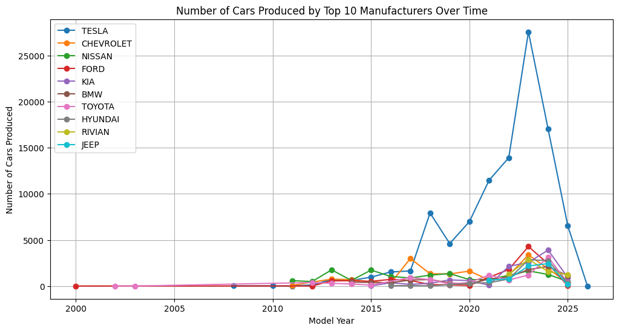

```python
import matplotlib.pyplot as plt
import pandas as pd

# Group data by company and model year, then count vehicles
company_model_year_counts = EV_df.groupby(['Make', 'Model Year'])['VIN (1-10)'].count().reset_index()
company_model_year_counts.rename(columns={'VIN (1-10)': 'Count'}, inplace=True)

# Get top 10 manufacturers
top_10_manufacturers = company_model_year_counts.groupby('Make')['Count'].sum().nlargest(10).index

# Filter data for top 10 manufacturers
filtered_data = company_model_year_counts[company_model_year_counts['Make'].isin(top_10_manufacturers)]

# Create plot
plt.figure(figsize=(12, 6))
for manufacturer in top_10_manufacturers:
    manufacturer_data = filtered_data[filtered_data['Make'] == manufacturer]
    plt.plot(manufacturer_data['Model Year'], manufacturer_data['Count'], marker='o', label=manufacturer)

plt.title('Number of Cars Produced by Top 10 Manufacturers Over Time')
plt.xlabel('Model Year')
plt.ylabel('Number of Cars Produced')
plt.grid(True)
plt.legend()
plt.show()
```

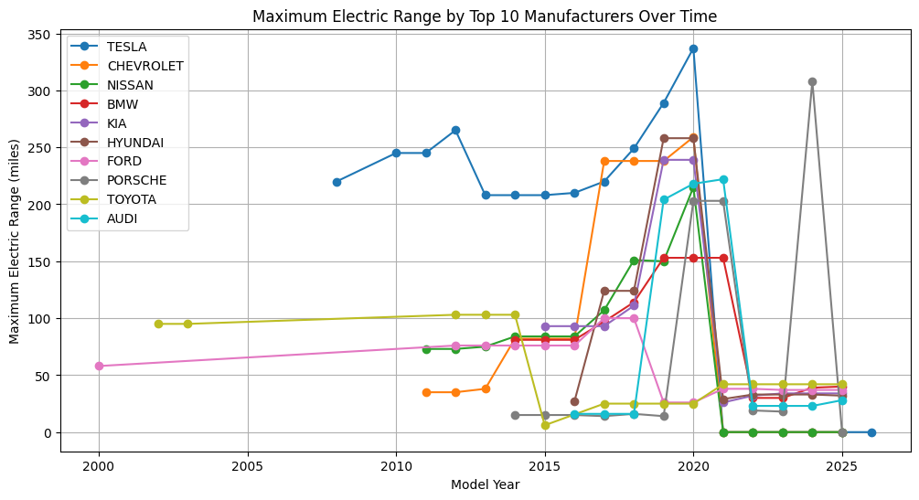

```python
import matplotlib.pyplot as plt
import pandas as pd

# Group data by company, model year, and get maximum electric range
company_model_year_max_range = EV_df.groupby(['Make', 'Model Year'])['Electric Range'].max().reset_index()

# Get top 10 manufacturers based on total electric range
top_10_manufacturers = company_model_year_max_range.groupby('Make')['Electric Range'].sum().nlargest(10).index

# Filter data for top 10 manufacturers
filtered_data = company_model_year_max_range[company_model_year_max_range['Make'].isin(top_10_manufacturers)]

# Create plot
plt.figure(figsize=(12, 6))
for manufacturer in top_10_manufacturers:
    manufacturer_data = filtered_data[filtered_data['Make'] == manufacturer]
    plt.plot(manufacturer_data['Model Year'], manufacturer_data['Electric Range'], marker='o', label=manufacturer)

plt.title('Maximum Electric Range by Top 10 Manufacturers Over Time')
plt.xlabel('Model Year')
plt.ylabel('Maximum Electric Range (miles)')
plt.grid(True)
plt.legend()
plt.show()
```

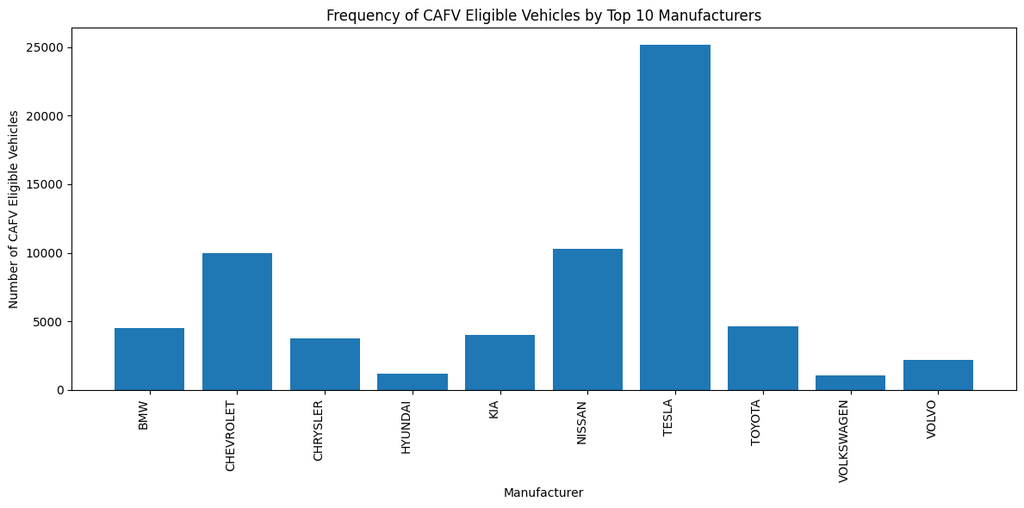

```python
# Group data by manufacturer and CAFV eligibility, then count vehicles
cafv_counts = EV_df.groupby(['Make', 'Clean Alternative Fuel Vehicle (CAFV) Eligibility'])['VIN (1-10)'].count().reset_index()
cafv_counts.rename(columns={'VIN (1-10)': 'Count'}, inplace=True)

# Filter for CAFV eligible vehicles
cafv_eligible_counts = cafv_counts[cafv_counts['Clean Alternative Fuel Vehicle (CAFV) Eligibility'] == 'Clean Alternative Fuel Vehicle Eligible']

# Get top 10 manufacturers based on CAFV eligible vehicle counts
top_10_manufacturers = cafv_eligible_counts.groupby('Make')['Count'].sum().nlargest(10).index

# Filter data for top 10 manufacturers
filtered_data = cafv_eligible_counts[cafv_eligible_counts['Make'].isin(top_10_manufacturers)]
# Create the bar chart
plt.figure(figsize=(12, 6))
plt.bar(filtered_data['Make'], filtered_data['Count'])
plt.xlabel("Manufacturer")
plt.ylabel("Number of CAFV Eligible Vehicles")
plt.title("Frequency of CAFV Eligible Vehicles by Top 10 Manufacturers")
plt.xticks(rotation=90, ha='right')  # Rotate x-axis labels for better readability
plt.tight_layout()  # Adjust layout to prevent labels from overlapping
plt.show()
```

**Clean Alternative Fuel Vehicle (CAFV) is another important factor to determine the quality of an electric vehicle. CAFV eligibility refers to a vehicle’s qualification to receive certain benefits or exemptions because it uses cleaner, alternative fuels rather than conventional gasoline or diesel. This eligibility is typically defined by state or federal government programs to promote environmentally friendly transportation.The above bar chart shows the frequency of CAFV eligible vehicles by top ten manufacturers. Based on the plot again Tesla is by far the leading player in this category too, followed by Nissan and Chevrolet and others.**

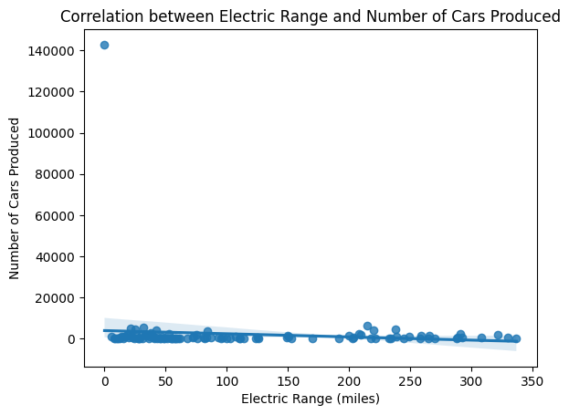

```python
import pandas as pd
import seaborn as sns
import matplotlib.pyplot as plt

# Group data by electric range and count the number of cars produced
range_counts = EV_df.groupby('Electric Range')['VIN (1-10)'].count().reset_index()
range_counts.rename(columns={'VIN (1-10)': 'Count'}, inplace=True)

# Create a scatter plot with a trend line using seaborn
sns.regplot(x='Electric Range', y='Count', data=range_counts)
plt.title('Correlation between Electric Range and Number of Cars Produced')
plt.xlabel('Electric Range (miles)')
plt.ylabel('Number of Cars Produced')
plt.show()
```

**The above plot shows a negative correlation between number of cars produced and electric range, the reason for that could be high price as we go towards higher electric range.**

```python
import pandas as pd
import numpy as np
from sklearn.linear_model import LinearRegression
import matplotlib.pyplot as plt
# Group data by model year and count vehicles
year_counts = EV_df.groupby('Model Year')['VIN (1-10)'].count().reset_index()
year_counts.rename(columns={'VIN (1-10)': 'Count'}, inplace=True)

# Extract years and counts
years = year_counts['Model Year'].values.reshape(-1, 1)
counts = year_counts['Count'].values
# Create a linear regression model
model = LinearRegression()

# Train the model
model.fit(years, counts)
# Predict the total number of electric vehicles after 10 years
future_year = 2023 + 10  # Assuming current year is 2023
future_year_reshaped = np.array([[future_year]])
predicted_count = model.predict(future_year_reshaped)

print(f"Predicted total number of electric vehicles after 10 years: {predicted_count[0]:.0f}")
```

```
Predicted total number of electric vehicles after 10 years: 34753
```

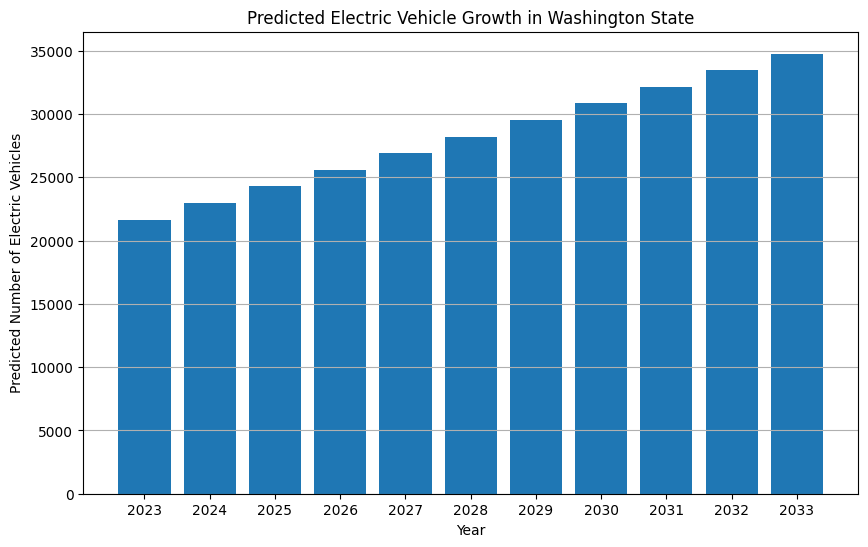

```python
import pandas as pd
import numpy as np
from sklearn.linear_model import LinearRegression
import matplotlib.pyplot as plt

# ... (previous code for prediction) ...

# Create a list of future years
future_years = np.arange(2023, 2023 + 11)  # Years from 2023 to 2033

# Predict the total number of electric vehicles for each future year
predicted_counts = model.predict(future_years.reshape(-1, 1))

# Create a bar chart
plt.figure(figsize=(10, 6))
plt.bar(future_years, predicted_counts)
plt.xlabel("Year")
plt.ylabel("Predicted Number of Electric Vehicles")
plt.title("Predicted Electric Vehicle Growth in Washington State")
plt.xticks(future_years)  # Set x-axis ticks to show all years
plt.grid(axis='y')  # Add gridlines for better readability
plt.show()
```

**A Linear Regression model is then applied to forecast annual electric vehicle production through 2033, covering a 10-year period beyond 2023. The projection indicates a steady increase each year, with production expected to reach approximately 35,000 electric vehicles by 2033 as shown in the plot above. For this prediction task, a linear regression model is used because It assumes a linear relationship between the year and the number of electric vehicles produced. If I had suspected a non-linear relationship, I also had the options to explore other regression models like polynomial regression or support vector regression.**

```python
# Group data by manufacturer and model year, then count vehicles
company_model_year_counts = EV_df.groupby(['Make', 'Model Year'])['VIN (1-10)'].count().reset_index()
company_model_year_counts.rename(columns={'VIN (1-10)': 'Count'}, inplace=True)
# Create a dictionary to store models for each manufacturer
manufacturer_models = {}

# Get unique manufacturers
manufacturers = company_model_year_counts['Make'].unique()

# Create and train a linear regression model for each manufacturer
for manufacturer in manufacturers:
    manufacturer_data = company_model_year_counts[company_model_year_counts['Make'] == manufacturer]
    years = manufacturer_data['Model Year'].values.reshape(-1, 1)
    counts = manufacturer_data['Count'].values
    model = LinearRegression()
    model.fit(years, counts)
    manufacturer_models[manufacturer] = model
# Get the predicted counts for the year 2043
#year_2043_counts = {manufacturer: counts[-1] for manufacturer, counts in predicted_counts.items()}
year_2043_counts = {}
for manufacturer, model in manufacturer_models.items():
    year_2043_counts[manufacturer] = model.predict([[2043]])[0] # Predict for year 2043
# Sort manufacturers by predicted counts in descending order
sorted_manufacturers = sorted(year_2043_counts.items(), key=lambda item: item[1], reverse=True)

# Get the top 10 manufacturers
top_10_manufacturers = [manufacturer for manufacturer, count in sorted_manufacturers[:10]]

print("Top 10 predicted leading electric vehicle manufacturers in 20 years:")
for manufacturer in top_10_manufacturers:
    print(manufacturer)
```

```
Top 10 predicted leading electric vehicle manufacturers in 20 years:
TESLA
KIA
HYUNDAI
SUBARU
BMW
CHEVROLET
VOLVO
MAZDA
FORD
VOLKSWAGEN
```

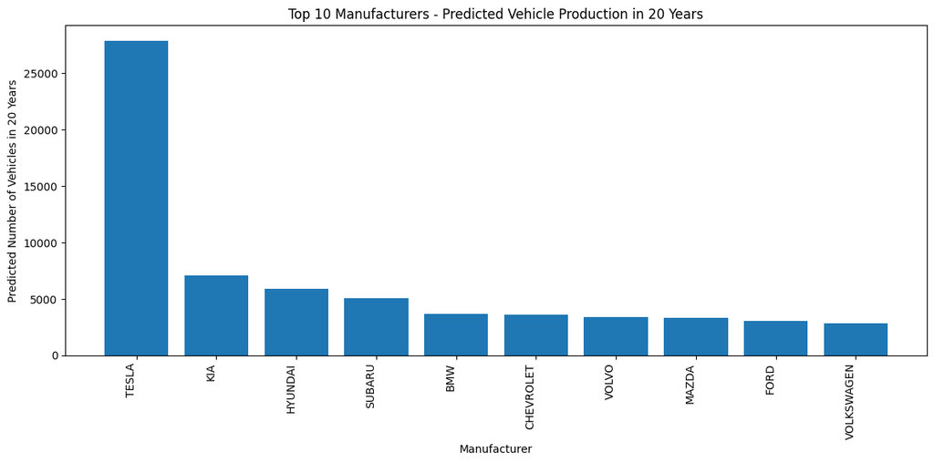

```python
# Create a bar chart
plt.figure(figsize=(12, 6))
plt.bar(top_10_manufacturers, [year_2043_counts[manufacturer] for manufacturer in top_10_manufacturers])
plt.xlabel("Manufacturer")
plt.ylabel("Predicted Number of Vehicles in 20 Years")
plt.title("Top 10 Manufacturers - Predicted Vehicle Production in 20 Years")
plt.xticks(rotation=90, ha='right')  # Rotate x-axis labels for better readability
plt.tight_layout()  # Adjust layout to prevent labels from overlapping
plt.show()
```

**Linear regression model is then applied again to predict top 10 biggest manufacturers of E-vehicles after 20 years following is the list of top 10 E-vehicle companies:** **TESLA** **KIA** **HYUNDAI** **SUBARU** **BMW** **CHEVROLET** **VOLVO** **MAZDA** **FORD** **VOLKSWAGEN**

**With Tesla being at 1st spot followed by Kia and then Hyundai.**

Conclusions: From my analysis of electric vehicle data in Washington State, I identified key trends such as the leading manufacturers, the total number of EVs in the state, the highest vehicle range achieved to date, and CAFV eligibility. Using these insights, I employed a linear regression model to forecast the total number of EVs in Washington over the next 10 years. Additionally, I used a similar linear regression approach to predict the top 10 competing manufacturers over the next 20 years.